# 의학통계방법론 1조 6주차 과제

김재혁, 정지현

2022-04-28

```r
getwd()
```

```
## [1] "C:/git_blog/study/data/ch14"
```

```r
library(foreign)
library(dplyr)
library(kableExtra)
library(broom)
```

## 0.1 14장

**14장 연습문제 불러오기**

```r
ex14_1a <- read.spss('Exam 14.1A.sav', to.data.frame=T)
```

## 0.2 EXAMPLE 14.1

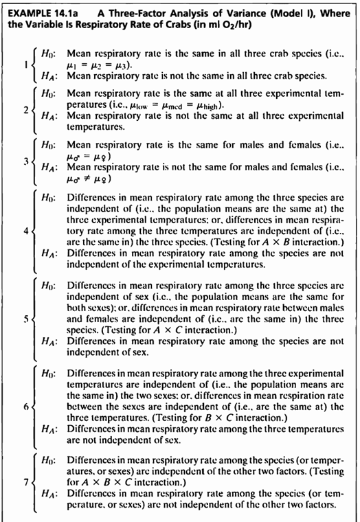

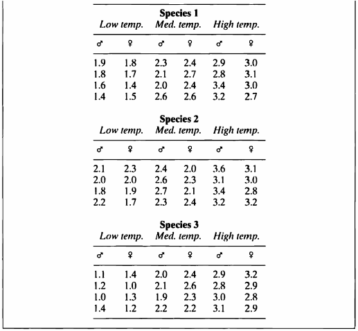

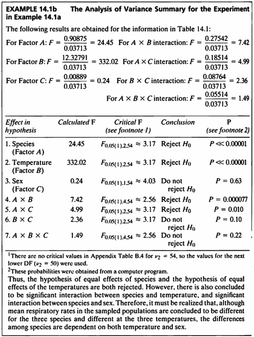

```r
#데이터셋
ex14_1a%>%
  kbl(caption = "Dataset",escape=F) %>%
  kable_styling(bootstrap_options = c("striped", "hover", "condensed", "responsive"))
```

Dataset

| Species | Sex | Temp | Y |
| --- | --- | --- | --- |
| 1 | 1 | 1 | 1.9 |
| 1 | 1 | 1 | 1.8 |
| 1 | 1 | 1 | 1.6 |
| 1 | 1 | 1 | 1.4 |
| 1 | 2 | 1 | 1.8 |
| 1 | 2 | 1 | 1.7 |
| 1 | 2 | 1 | 1.4 |
| 1 | 2 | 1 | 1.5 |
| 1 | 1 | 2 | 2.3 |
| 1 | 1 | 2 | 2.1 |
| 1 | 1 | 2 | 2.0 |
| 1 | 1 | 2 | 2.6 |
| 1 | 2 | 2 | 2.4 |
| 1 | 2 | 2 | 2.7 |
| 1 | 2 | 2 | 2.4 |
| 1 | 2 | 2 | 2.6 |
| 1 | 1 | 3 | 2.9 |
| 1 | 1 | 3 | 2.8 |
| 1 | 1 | 3 | 3.4 |
| 1 | 1 | 3 | 3.2 |
| 1 | 2 | 3 | 3.0 |
| 1 | 2 | 3 | 3.1 |
| 1 | 2 | 3 | 3.0 |
| 1 | 2 | 3 | 2.7 |
| 2 | 1 | 1 | 2.1 |
| 2 | 1 | 1 | 2.0 |
| 2 | 1 | 1 | 1.8 |
| 2 | 1 | 1 | 2.2 |
| 2 | 2 | 1 | 2.3 |
| 2 | 2 | 1 | 2.0 |
| 2 | 2 | 1 | 1.9 |
| 2 | 2 | 1 | 1.7 |
| 2 | 1 | 2 | 2.4 |
| 2 | 1 | 2 | 2.6 |
| 2 | 1 | 2 | 2.7 |
| 2 | 1 | 2 | 2.3 |
| 2 | 2 | 2 | 2.0 |
| 2 | 2 | 2 | 2.3 |
| 2 | 2 | 2 | 2.1 |
| 2 | 2 | 2 | 2.4 |
| 2 | 1 | 3 | 3.6 |
| 2 | 1 | 3 | 3.1 |
| 2 | 1 | 3 | 3.4 |
| 2 | 1 | 3 | 3.2 |
| 2 | 2 | 3 | 3.1 |
| 2 | 2 | 3 | 3.0 |
| 2 | 2 | 3 | 2.8 |
| 2 | 2 | 3 | 3.2 |
| 3 | 1 | 1 | 1.1 |
| 3 | 1 | 1 | 1.2 |
| 3 | 1 | 1 | 1.0 |
| 3 | 1 | 1 | 1.4 |
| 3 | 2 | 1 | 1.4 |
| 3 | 2 | 1 | 1.0 |
| 3 | 2 | 1 | 1.3 |
| 3 | 2 | 1 | 1.2 |
| 3 | 1 | 2 | 2.0 |
| 3 | 1 | 2 | 2.1 |
| 3 | 1 | 2 | 1.9 |
| 3 | 1 | 2 | 2.2 |
| 3 | 2 | 2 | 2.4 |
| 3 | 2 | 2 | 2.6 |
| 3 | 2 | 2 | 2.3 |
| 3 | 2 | 2 | 2.2 |
| 3 | 1 | 3 | 2.9 |
| 3 | 1 | 3 | 2.8 |
| 3 | 1 | 3 | 3.0 |
| 3 | 1 | 3 | 3.1 |
| 3 | 2 | 3 | 3.2 |
| 3 | 2 | 3 | 2.9 |
| 3 | 2 | 3 | 2.8 |
| 3 | 2 | 3 | 2.9 |

- 해당 데이터는 3 종류의 게의 데이터로 온도에 의한 산소 소비량을 기록한 데이터이다.
- 이 데이터를 사용하여 가능한 효과를 전부 포함한 완전모형에 대한 분산분석표를 작성하도록 한다.

```r
species <- as.factor(ex14_1a$Species)
temperature <- as.factor(ex14_1a$Temp)
sex <- as.factor(ex14_1a$Sex)
oxygen <- ex14_1a$Y

anova(aov(oxygen ~ species*temperature*sex)) %>%
  tidy() %>%
  rename(" "="term","Sum Sq"="sumsq","Mean Sq"="meansq","F value"="statistic","Pr(>F)"="p.value") %>%
  kable(caption = "Three-factor ANOVA",booktabs = TRUE, valign = 't') %>%
  kable_styling(bootstrap_options = c("striped", "hover", "condensed", "responsive"))
```

Three-factor ANOVA

|  | df | Sum Sq | Mean Sq | F value | Pr(>F) |
| --- | --- | --- | --- | --- | --- |
| species | 2 | 1.8175000 | 0.9087500 | 24.4750623 | 0.0000000 |
| temperature | 2 | 24.6558333 | 12.3279167 | 332.0236908 | 0.0000000 |
| sex | 1 | 0.0088889 | 0.0088889 | 0.2394015 | 0.6266204 |
| species:temperature | 4 | 1.1016667 | 0.2754167 | 7.4177057 | 0.0000775 |
| species:sex | 2 | 0.3702778 | 0.1851389 | 4.9862843 | 0.0102991 |
| temperature:sex | 2 | 0.1752778 | 0.0876389 | 2.3603491 | 0.1040564 |
| species:temperature:sex | 4 | 0.2205556 | 0.0551389 | 1.4850374 | 0.2195810 |
| Residuals | 54 | 2.0050000 | 0.0371296 | NA | NA |

> 첫번째 가설

$$\begin{aligned}
H_0 &: Mean \ respiratory \ rate \ is \ the \ same \ in \ all \
three \ crab \ species. \ (i.e., \ \mu_1=\mu_2=\mu_3) \\
H_1 &: Mean \ respiratory \ rate \ is \ not \ the \ same \ in \ all
\ three \ crab \ species.
\end{aligned}$$

- Species에 대한 F값은 24.475이며, p-value<0.0001 이므로 유의수준 5%하에 게들의 종류들 간에 차이가 있다고 할 수 있다.

> 두번째 가설

$$\begin{aligned}
H_0 &: Mean \ respiratory \ rate \ is \ the \ same \ at \ all \
three \ experimental \ temperatures. \ (i.e., \
\mu_{low}=\mu_{med}=\mu_{high}) \\
H_1 &: Mean \ respiratory \ rate \ is \ not \ the \ same \ at \ all
\ three \ experimental \ temperatures.
\end{aligned}$$

> 세번째 가설

$$\begin{aligned}
H_0 &: Mean \ respiratory \ rate \ is \ the \ same \ for \ males \
and \ females. \ (i.e., \ \mu_{male}=\mu_{female}) \\
H_1 &: Mean \ respiratory \ rate \ is \ not \ the \ same \ for \
males \ and \ females.
\end{aligned}$$

- 성별에 대한 F값은 0.24이며, p-value=0.626 이므로 유의수준 5%하에 성별 간 유의미한 차이가 있다고 할 수 없다.

> 네번째 가설
- 종과 온도의 상호작용에 대한 F값은 7.418이며, p-value<0.0001 이므로 유의수준 5%하에 게의 종과 온도에 대한 상호작용 효과가 있다고 할 수 있다.

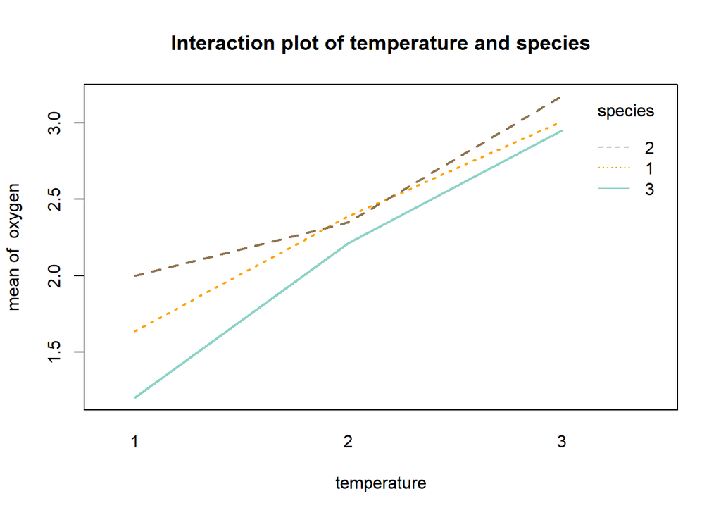

```r
interaction.plot(temperature,species,oxygen,col=c("orange","#8f7450","#8dd3c7"),main="Interaction plot of temperature and species",lwd=2)
```

- 그래프를 보면 온도가 높고 2번째 종인 경우가 평균 산소 소비량이 제일 큰 조합임을 알 수 있다.

> 다섯번째 가설
- 종과 성별의 상호작용에 대한 F값은 4.99이며, p-value=0.01 이므로 유의수준 5%하에 게의 종과 성별에 대한 상호작용 효과가 있다고 할 수 있다.

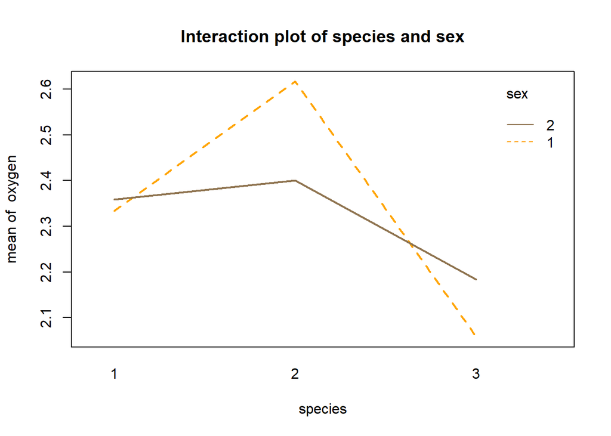

```r
interaction.plot(species,sex,oxygen,col=c("orange","#8f7450"),main="Interaction plot of species and sex",lwd=2)
```

- 그래프를 보면 성별이 남자고 2번째 종인 경우가 평균 산소 소비량이 제일 큰 조합임을 알 수 있다.

> 여섯번째 가설
- 온도와 성별의 상호작용에 대한 F값은 2.36이며, p-value=0.104 이므로 유의수준 5%하에 온도와 성별에 대한 상호작용 효과가 있다고 할 수 없다.

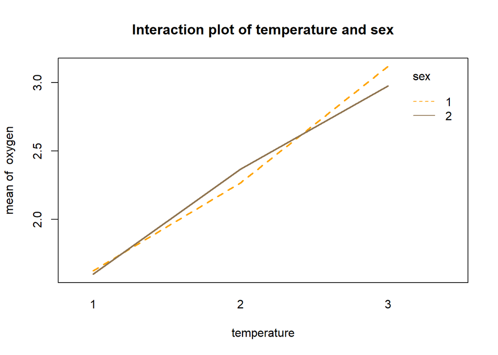

```r
interaction.plot(temperature,sex,oxygen,col=c("orange","#8f7450"),main="Interaction plot of temperature and sex",lwd=2)
```

- 그래프를 보면 성별이 남자고 온도가 높은 경우가 평균 산소 소비량이 제일 큰 조합임을 알 수 있다.

> 일곱번째 가설

-온도와 종과 성별 간의 상호작용에 대한 F값은 1.49이며, p-value=0.22로 유의수준 5%하에 온도와 종과 성별에 대한 상호작용 효과가 존재한다고 할 수 없다.